# Sesión 6

# ESTADISTICA PARA EL ANALISIS POLITICO II

- Profesor: [Dr. José Manuel Magallanes, Ph.D.](http://www.pucp.edu.pe/profesor/jose-manuel-magallanes/)
  - Profesor del Departamento de Ciencias Sociales, Sección de Ciencia Política y Gobierno.
  - [Oficina 105](https://goo.gl/maps/xuGeG6o9di1i1y5m6) - Edificio CISEPA / ECONOMIA / CCSS
  - Telefono: (51) 1 - 6262000 anexo 4302
  - Correo Electrónico: jmagallanes@pucp.edu.pe

## Análisis de Conglomerados (II)

Traigamos un archivo del COVID a nivel mundial:

```r
#limpiar memoria
rm(list = ls())
###
linkCovid="https://github.com/owid/covid-19-data/raw/master/public/data/owid-covid-data.csv"
allCovid=read.csv(linkCovid)
```

El objeto **allCovid** tiene esta cantidad de filas:

```r
nrow(allCovid)
```

```
## [1] 131500
```

El objeto **allCovid** tiene esta cantidad de columnas:

```r
ncol(allCovid)
```

```
## [1] 65
```

Veamos el tipo de dato *date*:

```r
str(allCovid$date)
```

```
##  chr [1:131500] "2020-02-24" "2020-02-25" "2020-02-26" "2020-02-27" ...
```

La fecha está como character, por lo que no se podría sacar cálculos:

```r
summary(allCovid$date)
```

```
##    Length     Class      Mode
##    131500 character character
```

Si deseas que sea fecha:

```r
allCovid$date=as.Date(allCovid$date,format="%Y-%m-%d")
```

Verificando:

```r
str(allCovid$date)
```

```
##  Date[1:131500], format: "2020-02-24" "2020-02-25" "2020-02-26" "2020-02-27" "2020-02-28" ...
```

Y calculando:

```r
summary(allCovid$date)
```

```
##         Min.      1st Qu.       Median         Mean      3rd Qu.         Max.
## "2020-01-01" "2020-08-11" "2021-01-21" "2021-01-12" "2021-06-17" "2021-11-06"
```

Quedémonos con los datos del 31 de julio de 2021:

```r
covidJulio21=allCovid[allCovid$date=="2021-07-31",]
```

Quedemonos con algunas variables, las cuáles están definidas aqui:

[interactive chart not shown]

Nos quedaremos con:

- **total_cases_per_million**: Total confirmed cases of COVID-19 per 1,000,000 people.
- **total_deaths_per_million**: Total deaths attributed to COVID-19 per 1,000,000 people.
- **aged_65_older**: Share of the population that is 65 years and older, most recent year available.
- **population_density**: Number of people divided by land area, measured in square kilometers, most recent year available

Seleccionemos esas variables, incluyendo **iso_code** y **location**:

```r
selec=c("iso_code","location","total_cases_per_million","total_deaths_per_million","aged_65_older","population_density")
covidJulio21=covidJulio21[,selec]
```

El **iso_code** es de tres caracteres, pero hay algunos de mayor tamaño:

```r
table(nchar(covidJulio21$iso_code))
```

```
##
##   3   8
## 219  15
```

Nos quedaremos con los que tienen sólo tres caracteres:

```r
covidJulio21=covidJulio21[nchar(covidJulio21$iso_code)==3,]
```

**covidJulio21** debe tener varios valores perdidos, veamos qué países los tienen:

```r
covidJulio21[!complete.cases(covidJulio21),"location"]
```

```
##  [1] "Andorra"                         "Anguilla"
##  [3] "Aruba"                           "Bermuda"
##  [5] "Bonaire Sint Eustatius and Saba" "British Virgin Islands"
##  [7] "Cayman Islands"                  "Cook Islands"
##  [9] "Curacao"                         "Dominica"
## [11] "Faeroe Islands"                  "French Polynesia"
## [13] "Gibraltar"                       "Greenland"
## [15] "Guernsey"                        "Isle of Man"
## [17] "Jersey"                          "Kiribati"
## [19] "Liechtenstein"                   "Macao"
## [21] "Marshall Islands"                "Micronesia (country)"
## [23] "Monaco"                          "Montserrat"
## [25] "Nauru"                           "New Caledonia"
## [27] "Niue"                            "Pitcairn"
## [29] "Saint Kitts and Nevis"           "Samoa"
## [31] "San Marino"                      "Sint Maarten (Dutch part)"
## [33] "Solomon Islands"                 "South Sudan"
## [35] "Syria"                           "Taiwan"
## [37] "Tokelau"                         "Tonga"
## [39] "Turkmenistan"                    "Turks and Caicos Islands"
## [41] "Tuvalu"                          "Vatican"
## [43] "Wallis and Futuna"
```

Omitiremos esos territorios:

```r
covidJulio21=covidJulio21[complete.cases(covidJulio21),]
```

Revisemos la data:

```r
summary(covidJulio21[,-c(1,2)])
```

```
##  total_cases_per_million total_deaths_per_million aged_65_older
##  Min.   :    12.72       Min.   :   0.341         Min.   : 1.144
##  1st Qu.:  3241.08       1st Qu.:  49.431         1st Qu.: 3.398
##  Median : 24004.31       Median : 336.365         Median : 6.258
##  Mean   : 38961.15       Mean   : 704.363         Mean   : 8.692
##  3rd Qu.: 66822.28       3rd Qu.:1114.480         3rd Qu.:14.211
##  Max.   :185299.77       Max.   :5885.985         Max.   :27.049
##  population_density
##  Min.   :   1.98
##  1st Qu.:  34.79
##  Median :  81.53
##  Mean   : 241.18
##  3rd Qu.: 204.79
##  Max.   :7915.73
```

La distribución de datos tiene rangos muy diferentes. Preparemos unos boxplot:

- Sin modificación:

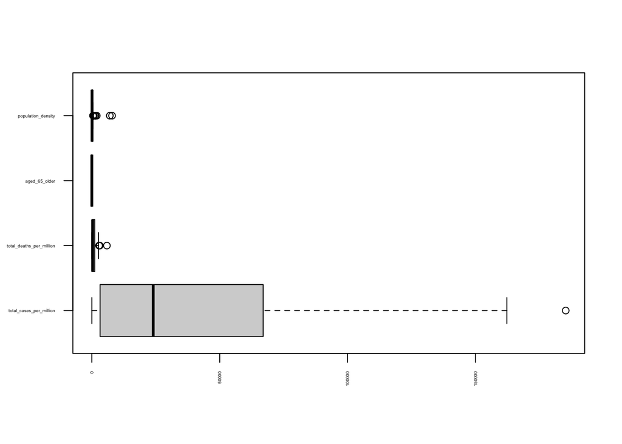

```r
boxplot(covidJulio21[,-c(1,2)],horizontal=T,las=2,cex.axis=0.3)
```

- Tipificado:

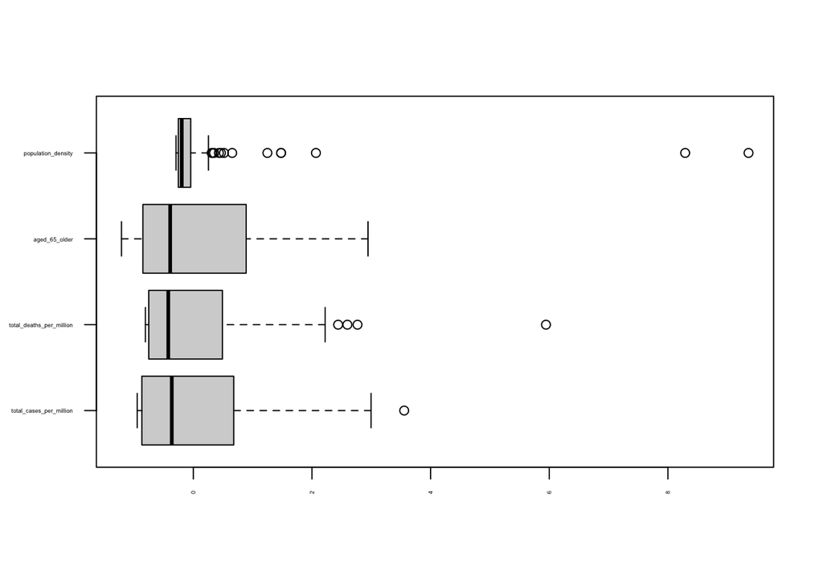

```r
boxplot(scale(covidJulio21[,-c(1,2)]),horizontal=T,las=2,cex.axis=0.3)
```

- Suavizado logarítmicamente:

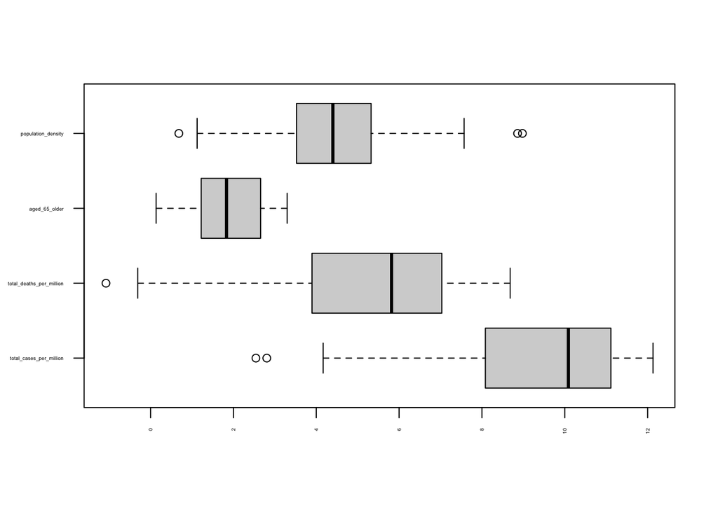

```r
boxplot(log(covidJulio21[,-c(1,2)]),horizontal=T,las=2,cex.axis=0.3)
```

La opción de convertir en logaritmo aleja menos las variables entre sí. Usemos eso:

```r
covidJulio21[,-c(1,2)]=log(covidJulio21[,-c(1,2)])
```

- Los nombres envialos como nombre de fila:

```r
row.names(covidJulio21)=covidJulio21$location
```

- Prepare los datos para el analisis cluster, use como semilla aleatoria al numero **123**.

```r
library(cluster)

set.seed(123)
g.dist = daisy(covidJulio21[,c(3:6)], metric="gower")
```

- Obtenga sugerencia de cantidad de clusters:

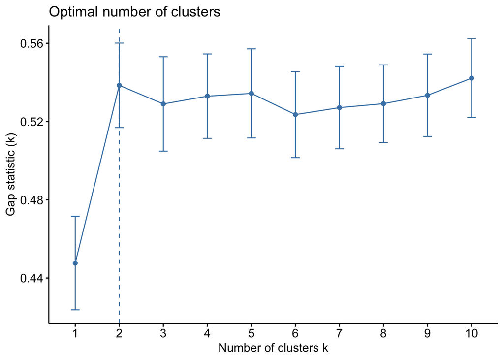

```r
## para PAM

library(factoextra)
fviz_nbclust(covidJulio21[,c(3:6)], pam,diss=g.dist,method = "gap_stat",k.max = 10,verbose = F)
```

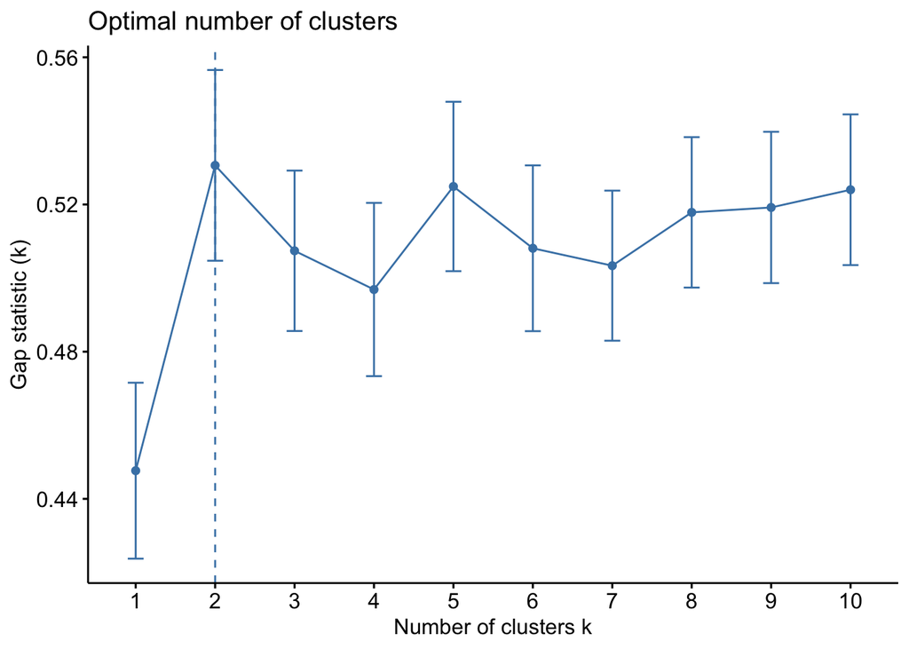

```r
## PARA JERARQUICO

fviz_nbclust(covidJulio21[,c(3:6)], hcut,diss=g.dist,method = "gap_stat",k.max = 10,verbose = F,hc_func = "agnes")
```

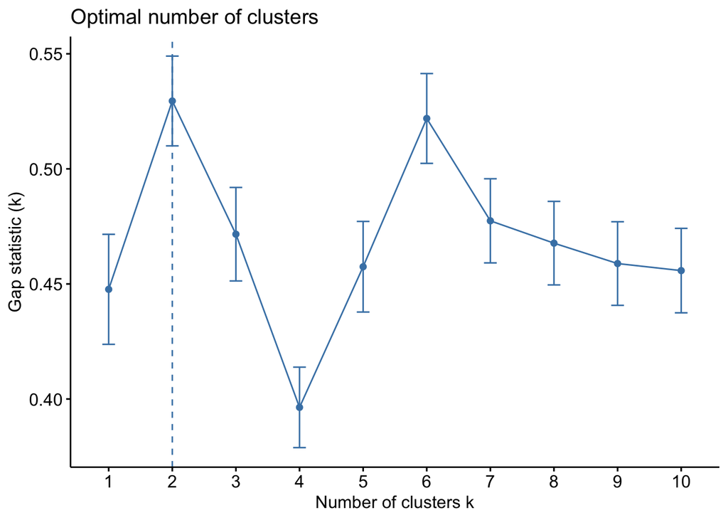

```r
## PARA JERARQUICO

fviz_nbclust(covidJulio21[,c(3:6)], hcut,diss=g.dist,method = "gap_stat",k.max = 10,verbose = F,hc_func = "diana")
```

Usemos la cantidad sugerida de clusters:

```r
set.seed(123)
SUGERIDOS=2
res.pam=pam(g.dist,k = SUGERIDOS,cluster.only = F)
covidJulio21$pam=res.pam$cluster
res.agnes <- hcut(g.dist, k = SUGERIDOS,hc_func='agnes')
covidJulio21$agnes=res.agnes$cluster
res.diana <- hcut(g.dist, k = SUGERIDOS,hc_func='diana')
covidJulio21$diana=res.diana$cluster
```

- Evaluemos el resultado usando el coeficiente de *silueta*:
- Un caso se ha clusterizado bien si tiene valor positivo
- Un caso es dificilmente clusterizable si es muy cercano a cero
- Un caso está mal clusterizado si es negativo.

```
##   cluster size ave.sil.width
## 1       1   71          0.43
## 2       2  105          0.46
```

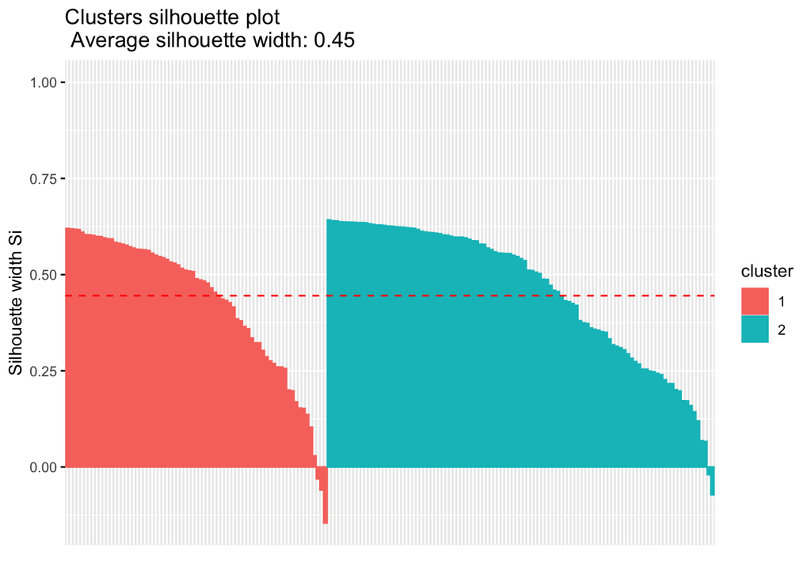

```r
fviz_silhouette(res.pam)
```

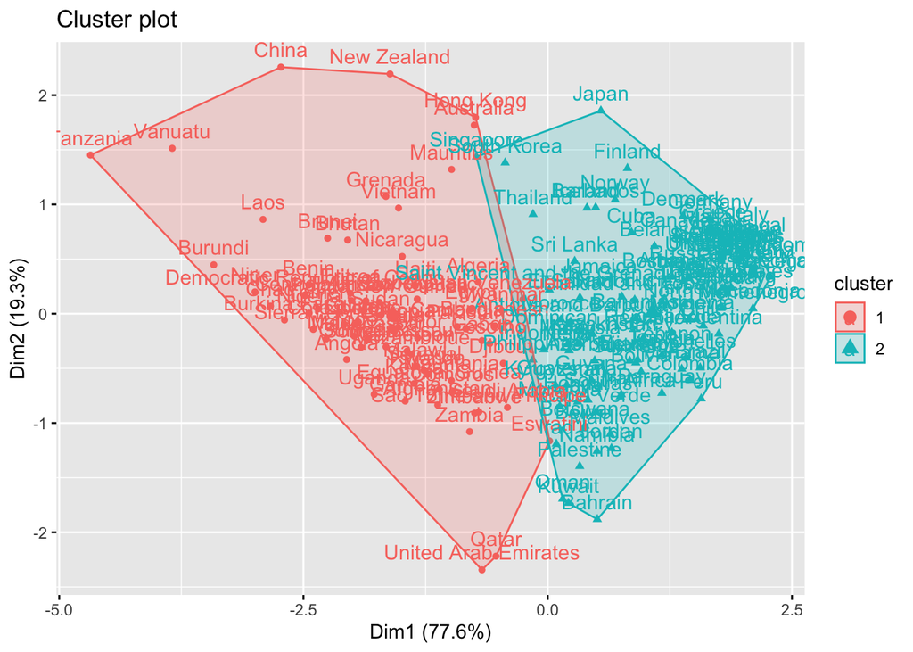

```r
fviz_cluster(list(data = covidJulio21[,c(3:5)], cluster = covidJulio21$pam))
```

```
##   cluster size ave.sil.width
## 1       1  136          0.32
## 2       2   40          0.58
```

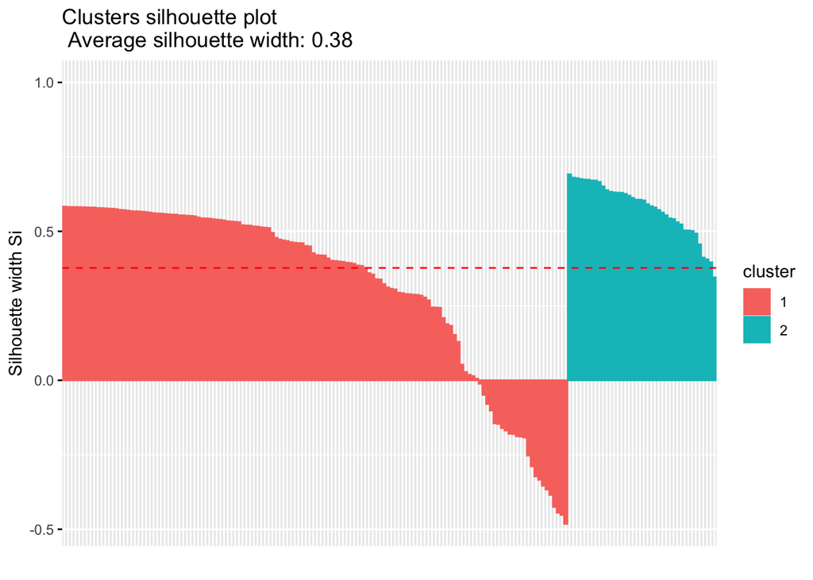

```r
fviz_silhouette(res.agnes)
```

```
##   cluster size ave.sil.width
## 1       1   70          0.44
## 2       2  106          0.47
```

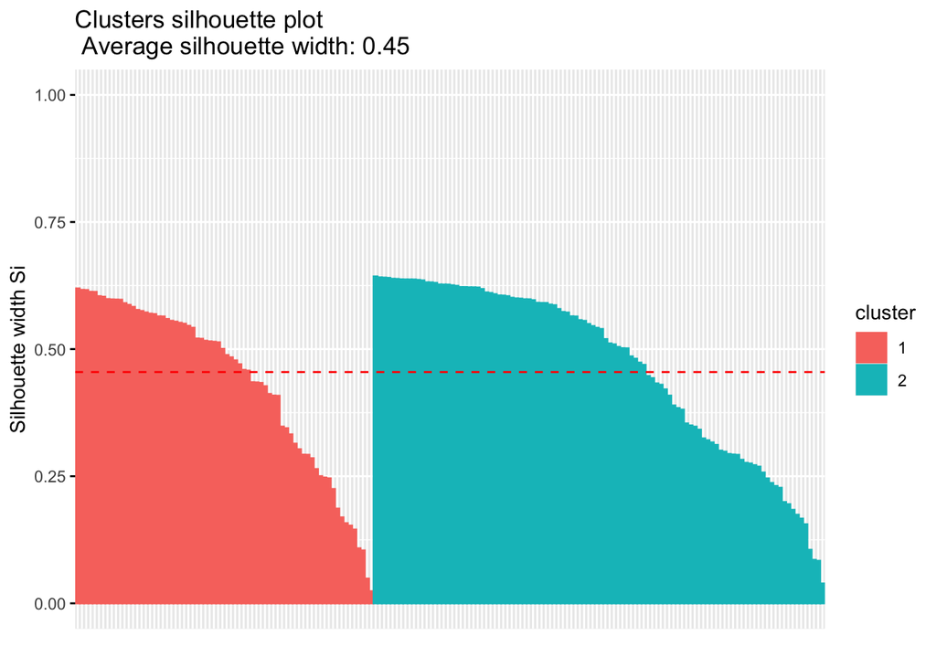

```r
fviz_silhouette(res.diana)
```

- El Dendograma puede apoyar a entender evaluación:

```r
dend1=pltree(res.agnes,cex = 0.5,hang = -1,main = "Agnes")
```

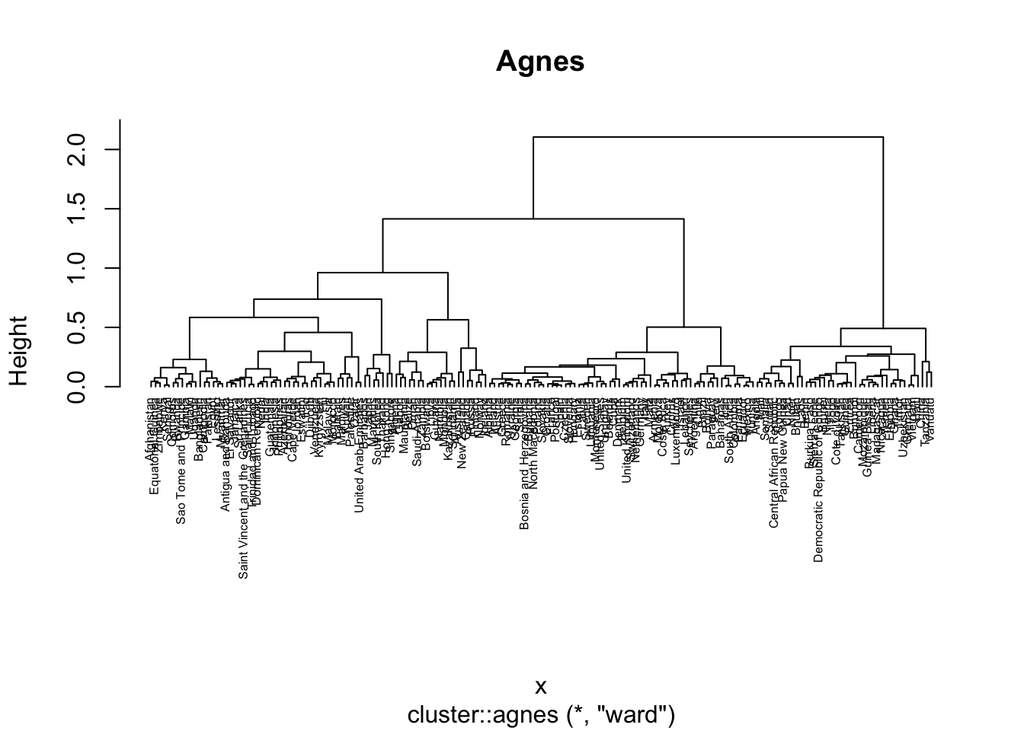

```r
dend2=pltree(res.diana,cex = 0.5,hang = -1,main = "Diana")
```

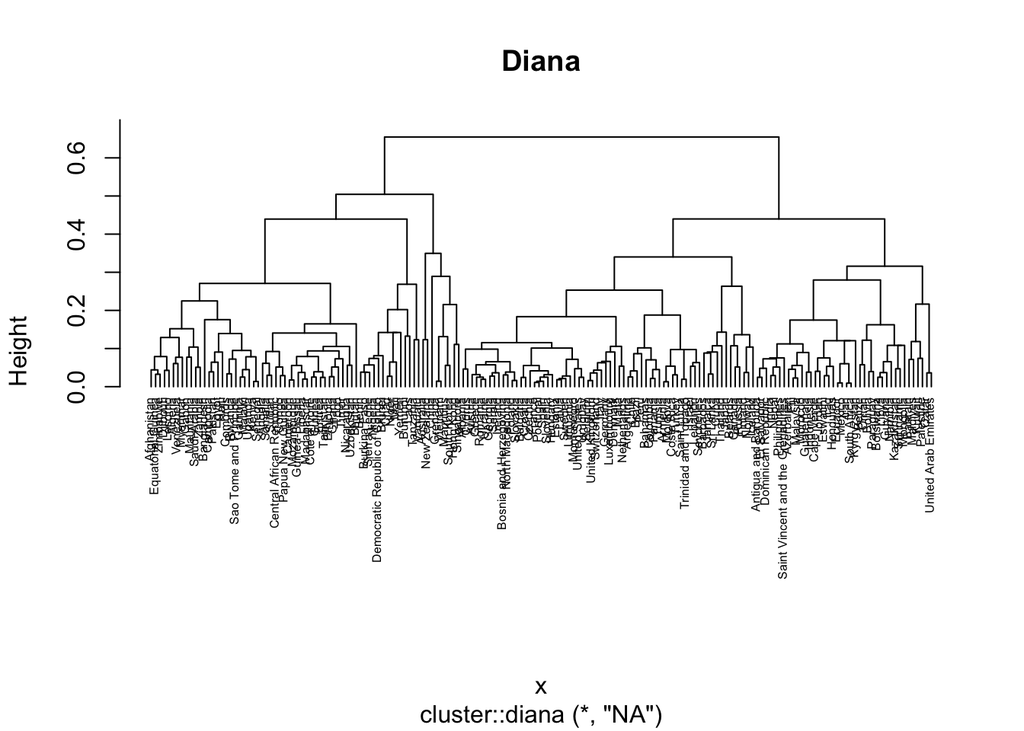

El *tanglegram* facilita la comparación:

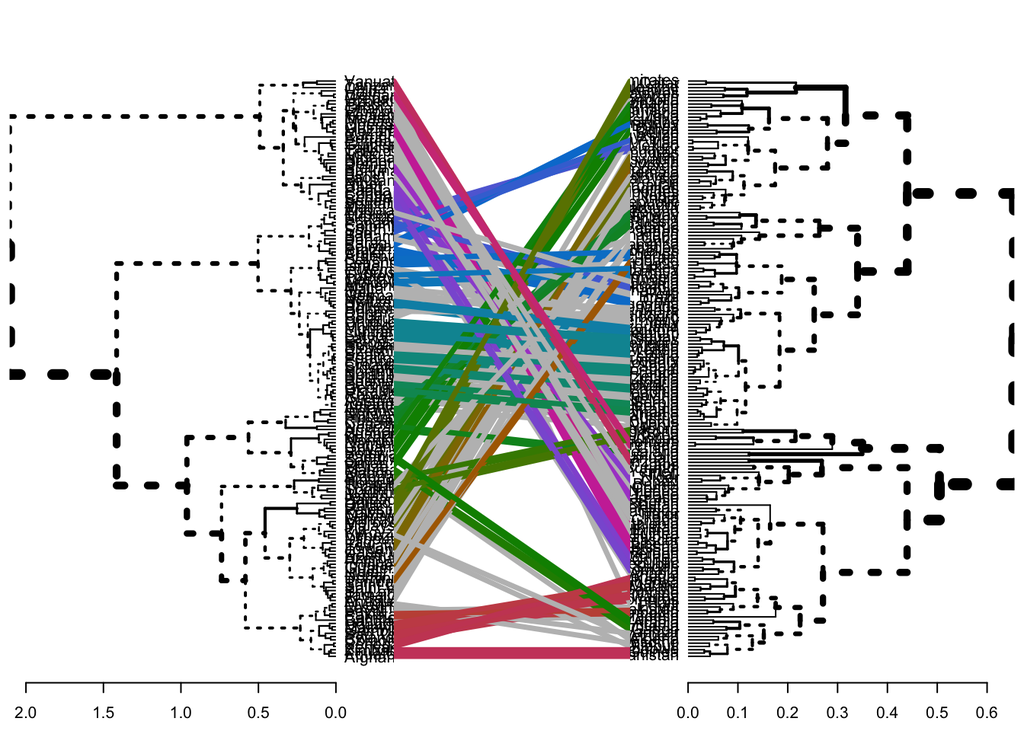

```r
library(dendextend)
dendAG <- as.dendrogram (res.agnes)
dendDI<- as.dendrogram (res.diana)
tanglegram(dendAG, dendDI)
```

- Encontremos los casos MAL clusterizados:

```r
silPAM=data.frame(res.pam$silinfo$widths)
silPAM$country=row.names(silPAM)
poorPAM=silPAM[silPAM$sil_width<0,'country']

silAGNES=data.frame(res.agnes$silinfo$widths)
silAGNES$country=row.names(silAGNES)
poorAGNES=silAGNES[silAGNES$sil_width<0,'country']

silDIANA=data.frame(res.diana$silinfo$widths)
silDIANA$country=row.names(silDIANA)
poorDIANA=silDIANA[silDIANA$sil_width<0,'country']
```

Juntemos todos en un Dataframe:

```r
library("qpcR")
mal_covidClus=as.data.frame(qpcR:::cbind.na(poorPAM, poorAGNES,poorDIANA))
mal_covidClus
```

```
##                 poorPAM             poorAGNES poorDIANA
## 1  United Arab Emirates              Djibouti      <NA>
## 2                 Qatar Sao Tome and Principe      <NA>
## 3              Eswatini               Lesotho      <NA>
## 4             Singapore             Hong Kong      <NA>
## 5           South Korea                 Gabon      <NA>
## 6                  <NA>                Zambia      <NA>
## 7                  <NA>              Zimbabwe      <NA>
## 8                  <NA>              Pakistan      <NA>
## 9                  <NA>               Algeria      <NA>
## 10                 <NA>             Australia      <NA>
## 11                 <NA>                 Egypt      <NA>
## 12                 <NA>               Comoros      <NA>
## 13                 <NA>             Mauritius      <NA>
## 14                 <NA>            Mauritania      <NA>
## 15                 <NA>              Cambodia      <NA>
## 16                 <NA>                Rwanda      <NA>
## 17                 <NA>           Afghanistan      <NA>
## 18                 <NA>           New Zealand      <NA>
## 19                 <NA>     Equatorial Guinea      <NA>
## 20                 <NA>                Gambia      <NA>
## 21                 <NA>                Malawi      <NA>
## 22                 <NA>               Senegal      <NA>
## 23                 <NA>                 Kenya      <NA>
## 24                 <NA>                Uganda      <NA>
```

- Podemos usar teoría de conjuntos para ver qué los casos mal clusterizados en todos las técnicas:

```r
intersect(poorPAM,poorAGNES)
```

```
## character(0)
```

```r
# en PAM pero NO en Agnes
setdiff(poorPAM,poorAGNES)
```

```
## [1] "United Arab Emirates" "Qatar"                "Eswatini"
## [4] "Singapore"            "South Korea"
```

```r
setdiff(poorAGNES,poorPAM)
```

```
##  [1] "Djibouti"              "Sao Tome and Principe" "Lesotho"
##  [4] "Hong Kong"             "Gabon"                 "Zambia"
##  [7] "Zimbabwe"              "Pakistan"              "Algeria"
## [10] "Australia"             "Egypt"                 "Comoros"
## [13] "Mauritius"             "Mauritania"            "Cambodia"
## [16] "Rwanda"                "Afghanistan"           "New Zealand"
## [19] "Equatorial Guinea"     "Gambia"                "Malawi"
## [22] "Senegal"               "Kenya"                 "Uganda"
```

```r
intersect(poorPAM,poorDIANA)
```

```
## character(0)
```

```r
intersect(poorAGNES,poorDIANA)
```

```
## character(0)
```

- **EJERCICIO**
1. Vuelva a hacer este ejemplo con TRES clusters.
2. Vuelva a hacer este ejemplo SIN MODIFICAR los datos originales.
3. Vuelva a hacer este ejemplo TIPIFICANDO en vez de suavizar explonencialmente los datos originales.
4. Haga todo lo anterior usando estas variables:
- people_fully_vaccinated_per_hundred: Total number of people who received all doses prescribed by the vaccination protocol per 100 people in the total population.
- gdp_per_capita: Gross domestic product at purchasing power parity (constant 2011 international dollars), most recent year available.
- hospital_beds_per_thousand: Hospital beds per 1,000 people, most recent year available since 2010.